# FoS_HW_02_Group_II

anon

2025-10-30

## Part I

##### **Topic**: Probability measures and distribution functions

### Exercise 1

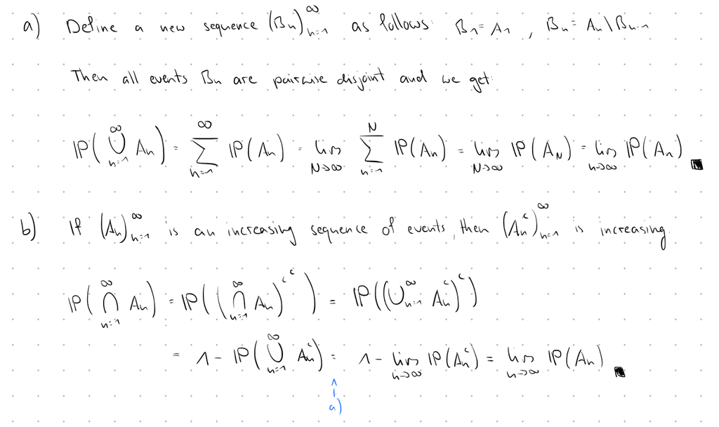

### Exercise 2

Let $(\Omega, \mathcal{A}, P)$ be a probability space and $X: \Omega \to \mathbb{R}$ be a random variable.

**Definition:** The cumulative distribution function (CDF) of $X$ is defined by
$$F(x) = P(X \leq x) \quad \text{for all } x \in
\mathbb{R}$$

#### a) Property 1: Monotonicity

**Theorem:** $F$ is monotonically increasing, i.e., for $x_1 < x_2$ we have $F(x_1) \leq F(x_2)$.

**Proof:**

$$A_1 = \{\omega \in \Omega:
X(\omega)\leq x_1\}$$
$$A_2 =
\{\omega \in \Omega: X(\omega)\leq x_2\}$$
Let $x_1 < x_2$. Then for the events:
$$A_1 \subseteq A_2$$
and thus
$$P(A_1) \leq P(A_2)$$
which is equal to
$$F(x) \leq F(y)$$
$\square$

#### b) Property 2: Limits

##### Part a: Limit at $-\infty$

**Theorem:** $\lim_{x \to -\infty} F(x) = 0$

**Proof:**

Let $(x_n)_{n \in \mathbb{N}}$ be a sequence with $x_n \to -\infty$ and $x_n \downarrow$ (e.g., $x_n = -n$).

Set $A_n = \{X \leq x_n\}$. Then:

- $(A_n)$ is a decreasing sequence of events and we have continuity from above $A_n\downarrow$
- $\bigcap_{n=1}^\infty A_n = \emptyset$ (since $x_n \rightarrow -\infty$)

By continuity from above:
$$\lim_{n \to
\infty} P(A_n) = P\left(\bigcap_{n=1}^\infty A_n\right) = P(\emptyset) =
0$$

Therefore

$$\lim_{n \to \infty} F(x_n) = 0 \quad
\square$$

##### Part b: Limit at $+\infty$

**Theorem:** $\lim_{x \to +\infty} F(x) = 1$

**Proof:**

Let $(x_n)_{n \in \mathbb{N}}$ be a sequence with $x_n \to +\infty$ and $x_n \uparrow$ (e.g., $x_n = n$).

Set $A_n = \{X \leq x_n\}$. Then:

- $(A_n)$ is an increasing sequence of events and we have continuity from below $A_n\uparrow$
- $\bigcup_{n=1}^\infty A_n = \Omega$ (since $x_n \rightarrow \infty$)

By continuity from below:
$$\lim_{n \to
\infty} P(A_n) = P\left(\bigcup_{n=1}^\infty A_n\right) = P(\Omega) =
1$$

Therefore

$$\lim_{n \to \infty} F(x_n) = 1
\quad \square$$

#### c) Property 3: Right-Continuity

**Theorem:** For all $x_0 \in \mathbb{R}$: $\lim_{x \to x_0^+} F(x) = F(x_0)$

$x \to x_0^+$ means $x$ approaches $x_0$ from the right (from above)

**Proof:**

Let $(x_n)$ be a sequence with $x_n \downarrow x_0$ (e.g., $x_n = x_0 + \frac{1}{n}$).

Set $A_n = \{X \leq x_n\}$ and $A = \{X \leq x_0\}$. Then:

- $(A_n)$ is a decreasing sequence
- $\bigcap_{n=1}^\infty A_n = A$ (since $X(\omega) \leq x_n \forall n$ $\Rightarrow$ $X(\omega) \leq x_0$)

By continuity from above:
$$\lim_{n \to
\infty} F(x_n) = \lim_{n \to \infty} P(A_n) = P(A) = F(x_0)\quad
\square$$

#### d ) F is left-limited

##### Statement to Prove

A distribution function $F$ is **left-limited** at each point $x \in \mathbb{R}$, i.e., the left-hand limit exists:

$$F(x^-) := \lim_{z \nearrow x} F(z)
\text{ exists for all } x \in \mathbb{R}$$

##### Properties of Distribution Functions

Recall that $F$ has the following properties:

1. **Monotone increasing**: For all $x \leq y$, we have $F(x) \leq F(y)$
2. **Right-continuous**: For all $x \in \mathbb{R}$, $\lim_{z \searrow x} F(z) = F(x)$
3. **Limits**: $\lim_{x \to -\infty} F(x) = 0$ and $\lim_{x \to \infty} F(x) = 1$

##### Proof

**Fix an arbitrary point $x \in \mathbb{R}$.**

##### Step 1: Define the set of left-hand values

Consider the set:
$$M = \{F(z) : z <
x\}$$

This is the set of all values that $F$ takes at points to the left of $x$.

##### Step 2: $M$ is bounded above

**Claim:** $M$ is bounded above.

**Proof:** For any $z < x$, the monotonicity of $F$ gives us $F(z) \leq F(x)$.

Therefore, $F(x)$ is an upper bound for $M$.

##### Step 3: The supremum exists

Since $M$ is non-empty ($F$ is defined on all of $\mathbb{R}$) and bounded above, by the **completeness axiom of $\mathbb{R}$**, the supremum exists:

$$L := \sup M = \sup\{F(z) : z <
x\}$$

##### Step 4: $L$ is the left-hand limit

**Claim:** $L = \lim_{z \nearrow x} F(z) = F(x^-)$

**Proof:** We must show that for every $\varepsilon > 0$, there exists $\delta > 0$ such that for all $z$ with $x - \delta < z < x$:

$$|F(z) - L| < \varepsilon$$

Let $\varepsilon > 0$ be given.

**Part A:** By definition of supremum, $F(z) \leq L$ for all $z < x$.

Therefore: $0 \leq L - F(z)$ for all $z < x$.

**Part B:** By the characterization of supremum, for any $\varepsilon > 0$, there exists $z_0 < x$ such that:

$$L - \varepsilon < F(z_0) \leq
L$$

(Otherwise, $L - \varepsilon$ would be a smaller upper bound, contradicting that $L$ is the *least* upper bound.)

**Part C:** Choose $\delta := x - z_0 > 0$.

For any $z$ with $x - \delta < z < x$, we have:

- $z_0 < z < x$ (by choice of $\delta$)
- $F(z_0) \leq F(z) \leq L$ (by monotonicity and Part A)
- $L - \varepsilon < F(z_0) \leq F(z) \leq L$ (combining with Part B)

Therefore:
$$L - \varepsilon < F(z)
\leq L$$

which gives us:
$$0 \leq L - F(z) <
\varepsilon$$

Hence:
$$|F(z) - L| <
\varepsilon$$

This proves that $\lim_{z \nearrow x} F(z) = L$.

**Conclusion**

We have shown that the left-hand limit $F(x^-) = \lim_{z \nearrow x} F(z)$ exists and equals:

$$F(x^-) = \sup\{F(z) : z < x\}\quad
\square$$

#### d ) Counterexample: F is not necessarily left-continuous

**Given:** F is left-limited, meaning the left limit F(x⁻) = lim_{z↗x} F(z) exists at every point x ∈ ℝ.

**To show:** F can satisfy F(x) ≠ F(x⁻), i.e., F is not necessarily left-continuous.

**Counterexample:**

Consider the CDF:
$$F(x) = \begin{cases}
0 & \text{if } x < 0 \\
1 & \text{if } x \geq 0
\end{cases}$$

This is the CDF of a point mass at x = 0.

**Evaluation at x = 0:**

**Left limit:**
$$F(0^-) =
\lim_{z \nearrow 0} F(z) = \lim_{z \nearrow 0} 0 = 0$$

(since F(z) = 0 for all z < 0)

**Function value:**
$$F(0) =
1$$

**Conclusion:**
$$F(0^-) = 0
\neq 1 = F(0)$$

Therefore, F is left-limited (the left limit exists) but **not left-continuous** at x = 0.

This demonstrates that a CDF can have $F(x) \neq F(x^-)\quad \square$.

#### (e)

For $x \le y$:

1. $$\{X \le y\} = \{X \le x\} \,\dot\cup\, \{x < X \le y\} \quad \implies
   \quad P(x < X \le y) = F(y) - F(x)$$
2. $$\{X \le y\} = \{X < x\} \,\dot\cup\, \{x \le X \le y\} \quad \implies
   \quad P(x \le X \le y) = F(y) - P(X < x) = F(y) - F(x^-)$$
3. $$\{X \le x\} = \{X < x\} \,\dot\cup\, \{X = x\} \quad \implies \quad
   P(X = x) = F(x) - F(x^-)$$

##### **Topic**: Conditional probability and independence

### Exercise 3

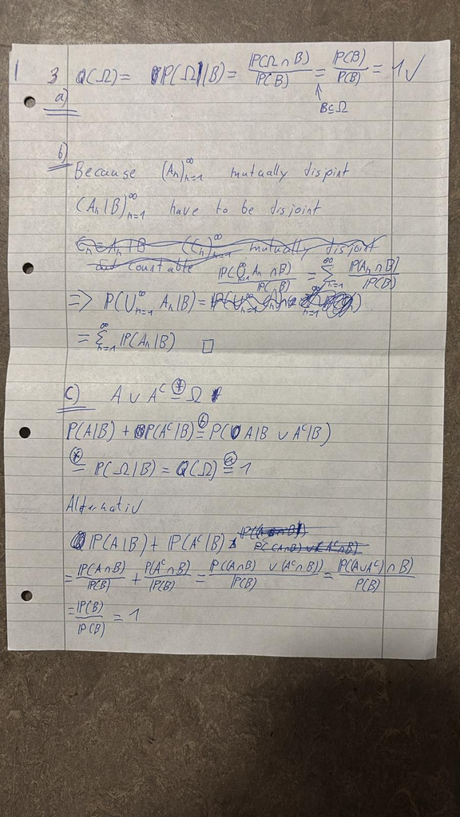

### Exercise 4

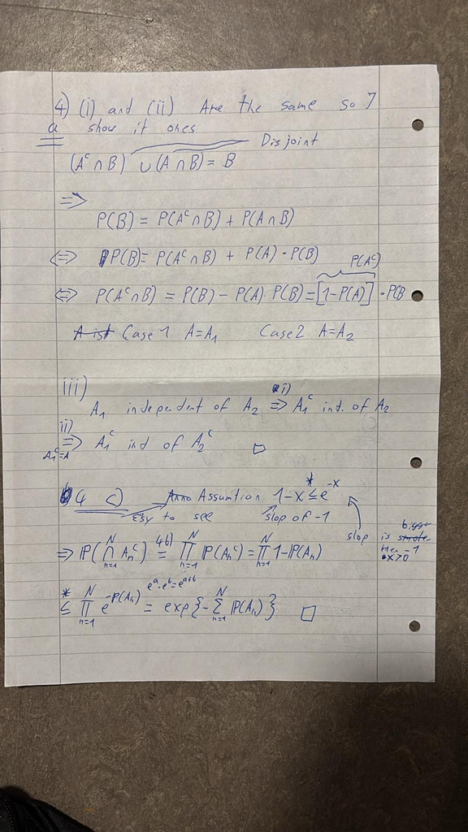

## Part II

### Exercise 5

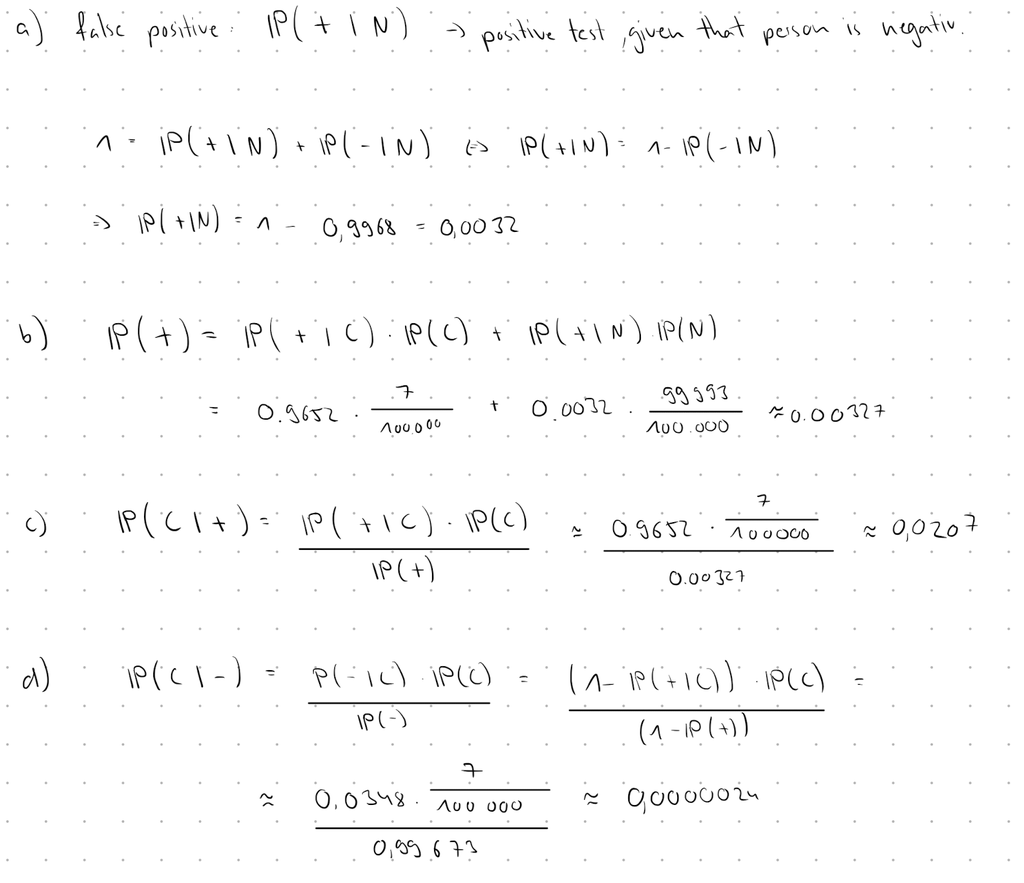

#### e), f)

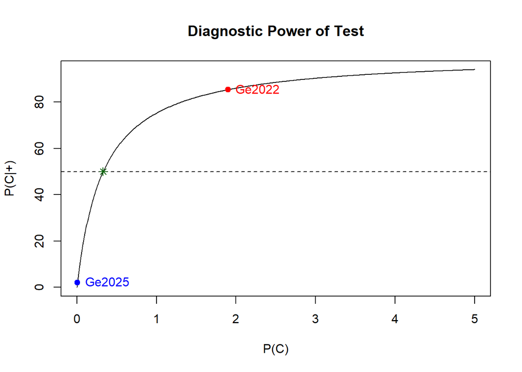

```r
# Given parameters
sens <- 0.9652
spec <- 0.9968
prob_false_pos <- 1 - spec

# Incidence rates (0% to 5%)
prob_C <- seq(0, 0.05, by = 0.0001)

# Compute P(C|+)
prob_C_given_pos <- (sens * prob_C) / (sens * prob_C + prob_false_pos * (1 - prob_C))

# Plot
plot(prob_C * 100, prob_C_given_pos * 100, type = "l",
     xlab = "P(C)",
     ylab = "P(C|+)",
     main = "Diagnostic Power of Test")

points(0.00007 * 100, 0.0207 * 100, col = "blue", pch = 19)
text(0.00007 * 100, 0.0207 * 100, "Ge2025", pos = 4, col = "blue")

points(0.019 * 100, 0.8538 * 100, col = "red", pch = 19)
text(0.019 * 100, 0.8538 * 100, "Ge2022", pos = 4, col = "red")

abline(h = 50, lty = 2)
prob_C_given_pos_50 <- 0.0033
points(prob_C_given_pos_50 * 100, 50, pch = 8, col = "darkgreen", cex = 1)
```

#### g)

```r
set.seed(420)
n <- 1000000
prob_C <- 0.00007

# Simulate infection status
C <- rbinom(n, 1, prob_C)
# Simulate test results
test_pos <- ifelse(C == 1,
                   rbinom(n, 1, sens),
                   rbinom(n, 1, 1 - spec))
# Estimate P(C|+)
P_C_given_pos_sim <- mean(C[test_pos == 1])
P_C_given_pos_sim
```

```
## [1] 0.01850139
```

##### **Topic**: The Hardy-Weinberg law in population genetics

## Part III

### Aufgabe 6

#### a)

Searched is; $P(Aa \cdot Aa \cap aa)$ Mating is independent:
$$P(Aa
\cdot Aa)=2q \cdot 2q = 4q^2$$

Offspring being aa:
$$P(aa|Aa \cdot Aa) =
\frac{1}{2} \cdot \frac{1}{2} = \frac{1}{4}$$
$P(A\cap B)=P(A) \cdot P(B|A)$:
$$P(Aa \cdot Aa \cap aa) = P(Aa\cdot Aa) \cdot
P(aa|Aa \cdot Aa)=4q^2\cdot \frac{1}{4}=q^2$$

#### b)

The question arises as to how much the individual genotypes contribute to A.

- $AA$: (guaranteed) A Allele $\rightarrow$ p
- $Aa$: half A Allele $\rightarrow$ q
- $aa$: zero A Allele $\rightarrow$ 0

Thus

- Total frequency of A: $p+q$
- analog for a: $r+q$

Offspring having AA in the first generation $p_1$
$$(p+q)\cdot(p+q)=(p+q)^2$$

Offspring having Aa in the first generation $2q_1$
$$(p+q)\cdot(r+q)+(r+q)\cdot(p+q)=2(r+q)\cdot(p+q)$$

Offspring having aa in the first generation $r_1$
$$(r+q)\cdot(r+q)=(r+q)^2$$

#### (c)

**Show:** $p_2 = p_1$, $2q_2 = 2q_1$, $r_2 = r_1$

**Frequency of $A$ in generation 1:**
$$p_1 + q_1 = (p+q)^2
+ (p+q)(r+q) = (p+q)\underbrace{((p+q) + (r+q))}_{=1}= (p+q) \cdot 1 =
p+q$$

**Frequency of $a$ in generation 1:**
$$r_1 + q_1 = (r+q)^2
+ (p+q)(r+q) = (r+q)[(r+q) + (p+q)] = (r+q) \cdot 1 = r+q$$

**Key observation**

The Allele frequencies in generation 1 are the **same** as in generation 0.

**Computing generation 2**

Since Allele frequencies are unchanged, applying the same logic as in part (b):

$$p_2 = (p+q)^2 = p_1$$
$$2q_2 = 2(p+q)(r+q) = 2q_1$$
$$r_2 = (r+q)^2 = r_1$$

#### (d)

**Show:** $p_n = p_1$, $2q_n = 2q_1$, $r_n = r_1$ for all $n \geq 1$

**Proof by induction:**

**Base case:** $n = 1$

Trivially true: $p_1 = p_1$, $2q_1 = 2q_1$, $r_1 = r_1$ ✓

**Inductive hypothesis:** Assume for some $k \geq 1$:
$$p_k = p_1, \quad 2q_k = 2q_1, \quad r_k =
r_1$$

**Inductive step:** Show $p_{k+1} = p_1$, $2q_{k+1} = 2q_1$, $r_{k+1} = r_1$.

From part (c), we know that if generation $k$ has frequencies $p_k, 2q_k, r_k$, then its allele frequencies are:
$$p_k + q_k = p_1 + q_1 = p
+ q$$
$$r_k + q_k = r_1 + q_1 = r +
q$$

Applying random mating to generation $k$:
$$p_{k+1} =
(p_k + q_k)^2 = (p+q)^2 = p_1$$
$$2q_{k+1} = 2(p_k + q_k)(r_k + q_k) = 2(p+q)(r+q)
= 2q_1$$
$$r_{k+1} = (r_k + q_k)^2 =
(r+q)^2 = r_1$$

By induction, the result holds for all $n \geq 1$. $\square$

### Hardy-Weinberg Law

**Conclusion:** After one generation of random mating, genotype frequencies reach equilibrium and remain constant forever:

$$\boxed{p_n = (p+q)^2, \quad 2q_n =
2(p+q)(r+q), \quad r_n = (r+q)^2 \quad \forall n \geq 1}$$

**Implications:**

**(i)** No evolutionary change occurs through reproduction alone.

**(ii)** Changes in allele/genotype frequencies require additional forces:

- Natural selection
- Genetic drift
- Mutations
- Migration